# Comparison of normal and Trichinella spiralis infected Rattus norvegicus gastrointestinal fluids by MALDI-TOF-MS

Martin

30/8/2019

# Objetivos del experimento

Determinar difererencias significativas en las intensidades de las señales de los espectros de MALDI-TOF-MS de fluidos intestinales de ratas normales e infectadas con T. spiralis.

Asociar los picos significativamente diferenciales con proteínas descriptas en bases de datos, (búsqueda bio-informática).

# Materiales y metodología

Fluidos intestinales…

Se colocó 1µl de fluido intestinal junto con 0.8 µl de matriz HCCA en la placa del equipo de MALDI-TOF (Autoflex; Bruker Daltonics) por dúplicado biológico y se realizaron triplicados técnicos.

Los perfiles fueron generados por un modificación del método MBT en el rango 2-20 kDa, en la cual se aumentó la intensidad al 60%. Los espectros se generaron de modo manual alcanazando sumas de 440 adquisiones (11 por espectro) y se analizaron con el software RStudio.

# Resultados

## Visualización de espectros

La siguiente visualización muestra todos los espectros de los grupos control e infectado promediados. Puede apreciarse que los espectros difieren en varias zonas del rango m/z.

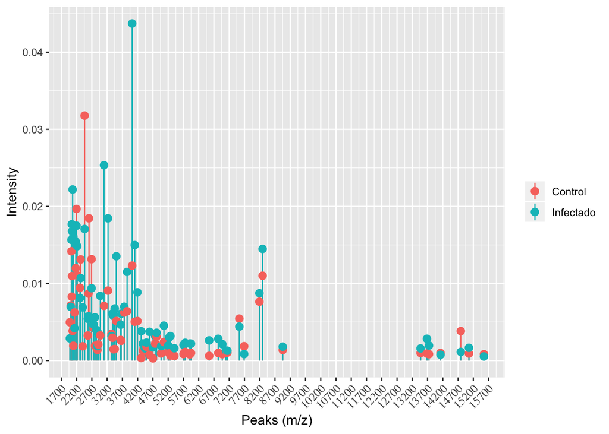

## Análisis estadísticos no supervisados

Para realizar estos análisis, se consideraron como unidades experimentales los duplicados técnicos de modo que dentro del grupo infectado aparecen 12 unidades y dentro del control 8. Cada una de estas se proceso por triplicado y cada espectro es la resultante del promedio de esos triplicados. En total se adquirieron 60 espectros ((12*3) + (8*3)).

### Hierarchical k-means clustering

Cada punto del gráfico representa un espectro con todas sus intensidades.

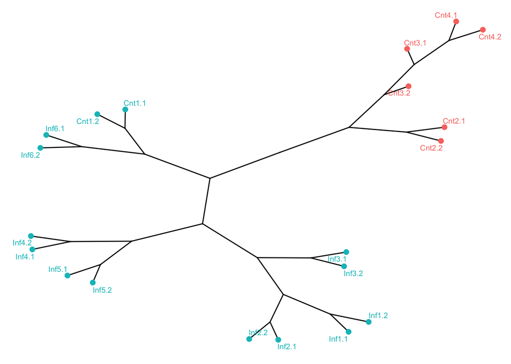

Solo uno de los controles (Cnt1.1 y Cnt1.2) parecería tener un perfil más similar a los infectados. Los perfiles obtenidos de esta manera parecerían reflejar diferencias entre ambos líquidos biológicos.

## Análisis estadísticos supervisados

### Linear discriminant analysis (LDA)

El gráfico muestra los 20 picos con expresión diferencial detectados por este algortimo. Se comparan los t-scores para cada pico entre y dentro los grupos. Valores positivos de estos scores indican presencia y los negativos ausencia dentro de ese grupo.

[figure not shown]

### Binary discriminant analysis (BDA)

El gráfico muestra los 20 picos con expresión diferencial detectados por este algortimo, en el que se comparan los t-scores para cada pico entre y dentro los grupos. Valores positivos de estos scores indican presencia y los negativos ausencia dentro de ese grupo.

[figure not shown]

### Random forest

```
## [1] "Random Forest"
##       acc      sens      spec       ppv       npv       lor
## 0.7500000 0.6666667 1.0000000 1.0000000 0.5000000       Inf
## attr(,"negative")
## [1] "Control"
```

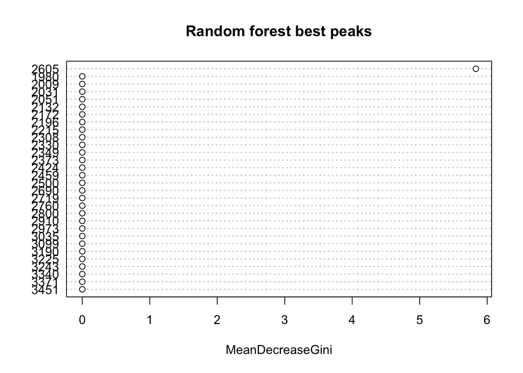

Este algoritmo detecta sólo 1 pico diferencial entre ambos grupos.

## Asignación bio-informática de picos

Con el peso molecular obtenido para los picos signifcativos detectados por los algoritmos y la especie del animal (Rattus norvegicus), se realizó la búsqueda en la base de datos de expasy.

https://web.expasy.org/cgi-bin/tagident/tagident0.pl

## Confiables

### 4312

El pico con mayor diferencia significativa entre control e infectado por BDA y LDA.

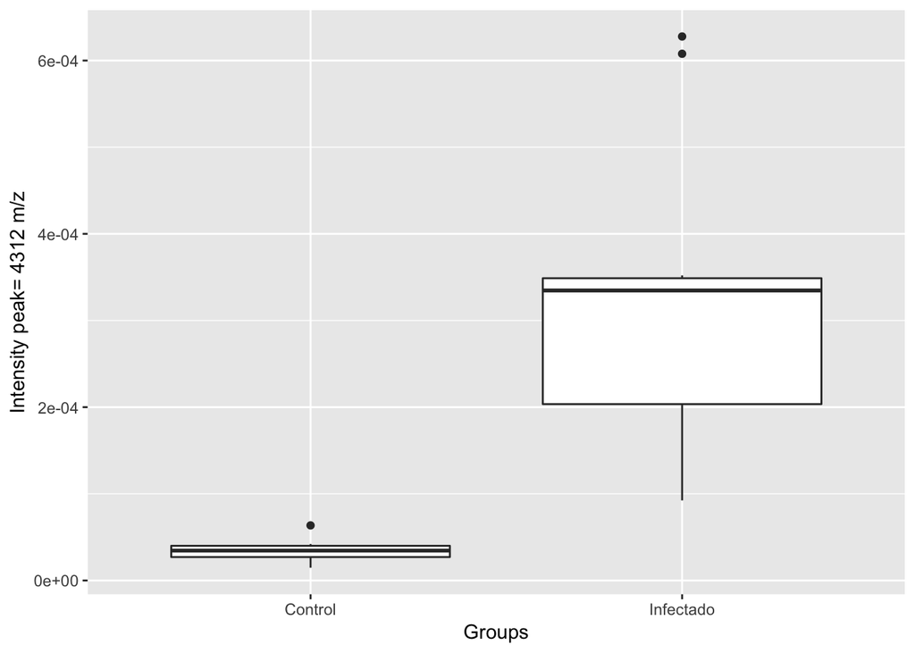

**Expasy**

PCSK1_RAT (Q9QXU9) Big PEN-LEN. {ECO:0000250}. Chain: 221-260, pI: 6.33, **Mw: 4314**

La diferencia de masa esta dentro del límite aceptable.

**interprot**

Homology with Protein: ProSAAS Gene: Pcsk1n Organism: Rattus norvegicus (Rat)

Golgi and secreted

May function in the control of the neuroendocrine secretory pathway. Proposed be a specific endogenous inhibitor of PCSK1. ProSAAS and Big PEN-LEN, both containing the C-terminal inhibitory domain, but not the processed peptides reduce PCSK1 activity in the endoplasmic reticulum and Golgi.

It reduces the activity of the 87 kDa form but not the autocatalytically derived 65 kDa form of PCSK1. Subsequent processing of proSAAS may eliminate the inhibition. Slows down convertase-mediated processing of proopiomelanocortin and proenkephalin. May control the intracellular timing of PCSK1 rather than its total level of activity. The function of the processed secreted peptides is not known.

Expressed in adult brain (all major structural regions), adrenal gland (medulla) and spinal chord (dorsal and ventral horn). Expressed in pancreatic islands.

Expressed by E12.5 in essentially all differentiating neurons in the mantle layer of the myelencephalon, metencephalon, diencephalon, spinal cord and several sympathetic ganglia. During later stages of prenatal development, widespread expression continues in post-mitotic neurons of both the CNS and PNS and begins in endocrine cells of the anterior and intermediate pituitary.

No presenta homólogos en Trichinella spiralis (taxid:6334), Trichinella spp (taxid:6333) ni nematode (taxid:6231).

### 3340

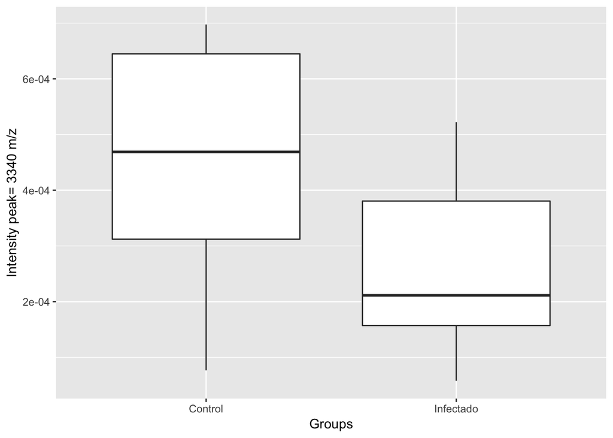

**Expasy**

DEF4_RAT (Q62714) Neutrophil antibiotic peptide NP-4. Chain: 63-93, pI: 8.97, **Mw: 3339**

La diferencia de m/z esta dentro del límite aceptable.

**interprot**

Belongs to the alpha-defensin family.

### 2605

El único pico detectado por los tres algoritmos.

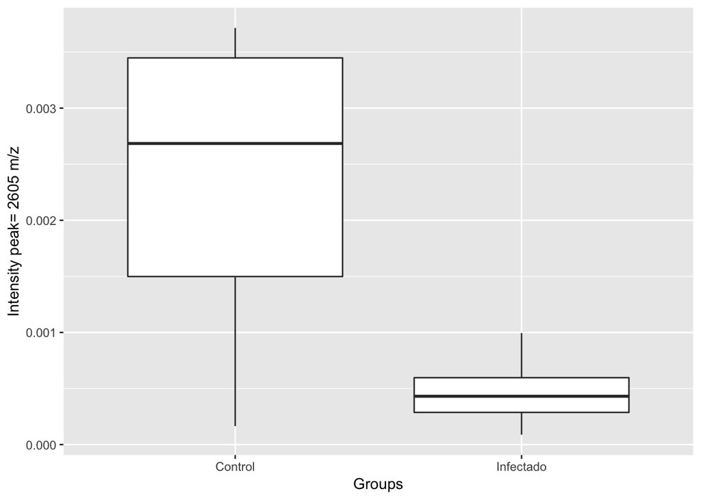

**Expasy**

NPW_RAT (Q8K1M5) Neuropeptide W-23. Chain: 42-64, pI: 10.27, **Mw: 2600**

La diferencia de masa esta dentro del límite aceptable.

**interprot**

Protein: Neuropeptide W Gene: Npw Organism: Rattus norvegicus (Rat)

Plays a regulatory role in the organization of neuroendocrine signals accessing the anterior pituitary gland. Stimulates water drinking and food intake. May play a role in the hypothalamic response to stress. When injected into the lateral cerebroventricle, it elevates prolactin (PRL) and corticosterone and lowers growth hormone (GH) release.

In addition to the reproductive and immune tissues in which neuropeptide B is expressed, neuropeptide W has been found at high levels in the liver, stomach and trachea.

No presenta homólogos en Trichinella spiralis (taxid:6334), Trichinella spp (taxid:6333) ni nematode (taxid:6231).

Decaprenyl-diphosphate synthase subunit 2 [Trichinella spiralis]: Cover 20%, Identity 39.5% No llega a ser homóloga.

### 7700

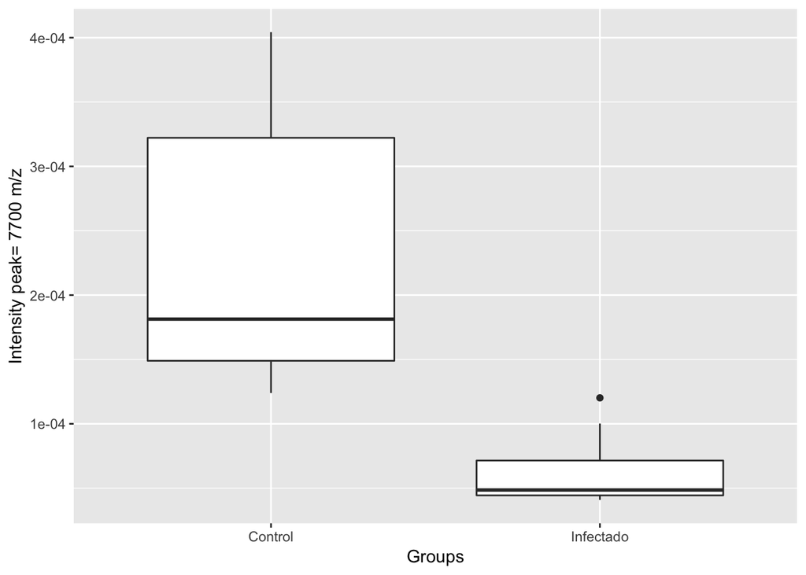

**Expasy**

M0R807_RAT (M0R807) SubName: Full=RCG59134 {ECO:0000313|EMBL:EDL82924.1};0000… Chain: 1-68, pI: 10.42, **Mw: 7704**

La diferencia de masa esta dentro del límite aceptable.

**interprot**

Protein: Submitted name: RCG59134 Gene: Smlr1 Organism: Rattus norvegicus (Rat)

Predicted to localize to the integral component of membrane; orthologous to human SMLR1 (small leucine rich protein 1); INTERACTS WITH 3-chloropropane-1,2-diol; bisphenol A; cobalt dichloride.

Se expresa en higado>riñon>colon.

Su homólogo de homo sapiens interactua con serpina (Thyroxine-binding globulin; Major thyroid hormone transport protein in serum; Belongs to the serpin family) y con Apolipoprotein C-III.

### 2973

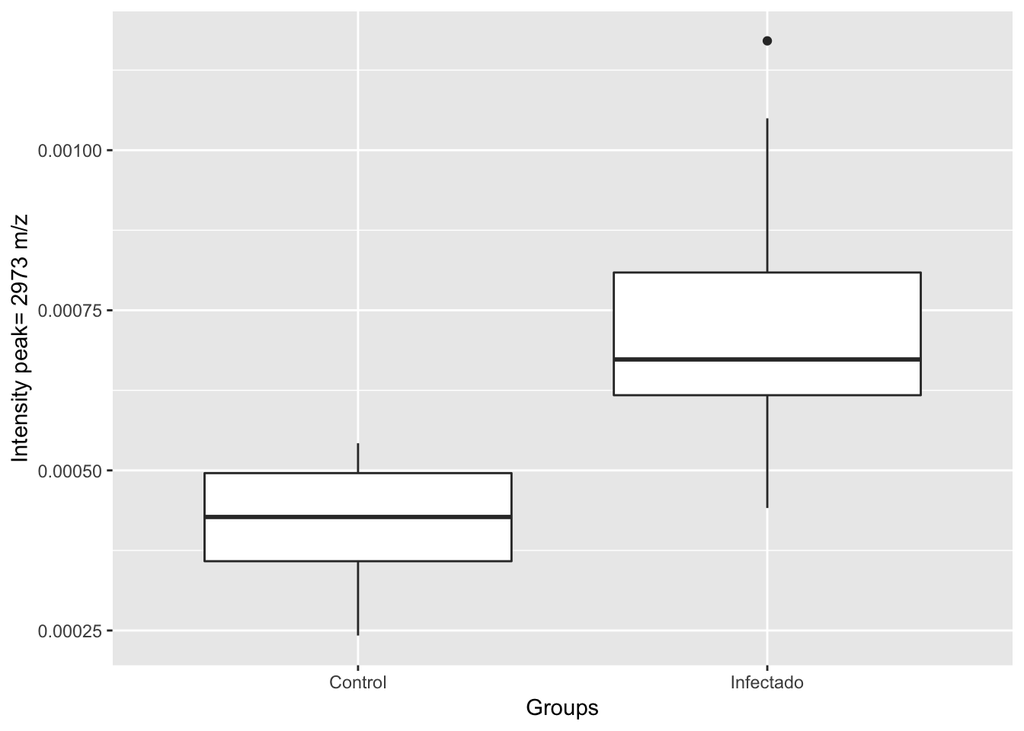

**Expasy**

ANFC_RAT (P55207) CNP-29. {ECO:0000250}. Chain: 98-126, pI: 9.78, **Mw: 2976**

**interprot**

Protein: C-type natriuretic peptide Gene: Nppc Organism: Rattus norvegicus (Rat)

Se expresa en cólon.

Hormone which plays a role in endochondral ossification through regulation of cartilaginous growth plate chondrocytes proliferation and differentiation. May also be vasoactive and natriuretic. Specifically binds and stimulates the cGMP production of the NPR2 receptor. Binds the clearance receptor NPR3.

### 3451

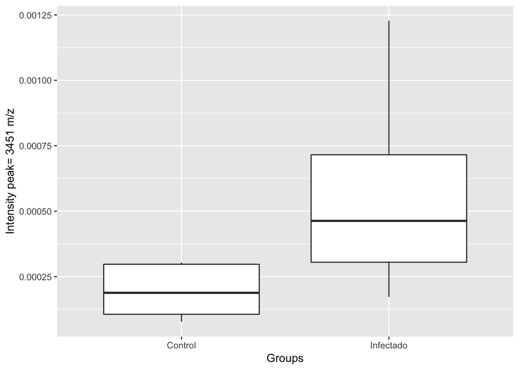

**Expasy**

RL41_RAT (P62948) 60S ribosomal protein L41. Chain: 1-25, pI: 12.95, **Mw: 3456**

### 6543

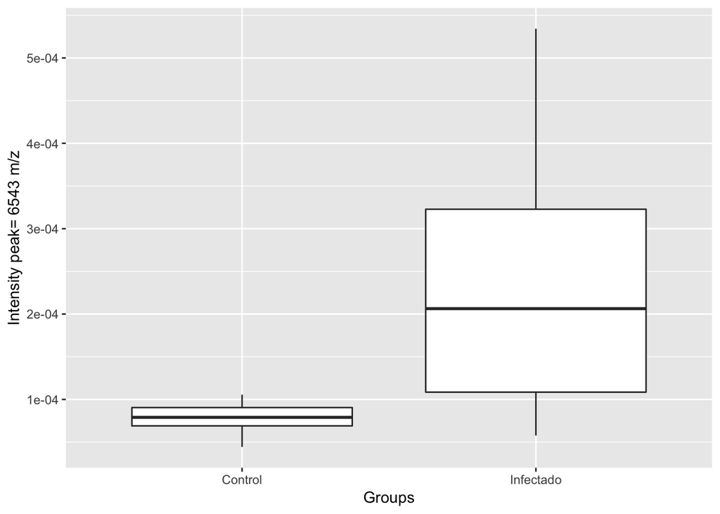

**Expasy1**

RS29_RAT (P62275) 40S ribosomal protein S29. Chain: 2-56, pI: 10.16, **Mw: 6546**

**interprot1**

Protein: 40S ribosomal protein S29 Gene: Rps29 OrganismRattus norvegicus (Rat)

### 13674

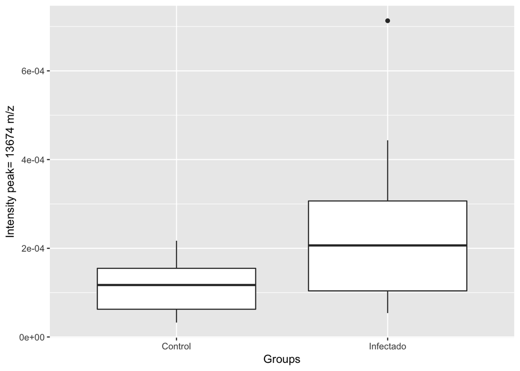

SMR2_RAT (P18897) SMR2 protein. Chain: 19-137, pI: 4.61, Mw: 13675

Protein: SMR2 protein Gene: Smr2 Organism: Rattus norvegicus (Rat)

proline-rich proteins (PRPs)

### 3035

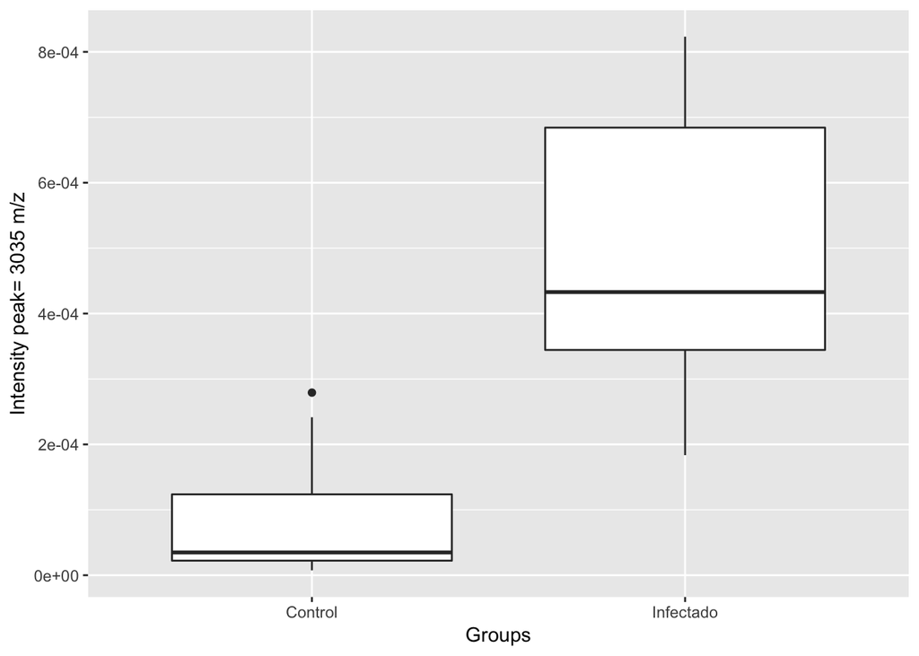

**Expasy**

PAHO_RAT (P06303) C-terminal peptide. Chain: 69-98, pI: 4.55, **Mw: 3041**

**interprot**

Protein: Pancreatic prohormone Gene: Ppy Organism: Rattus norvegicus (Rat)

Pancreatic hormone is synthesized in pancreatic islets of Langerhans and acts as a regulator of pancreatic and gastrointestinal functions.

### 3747

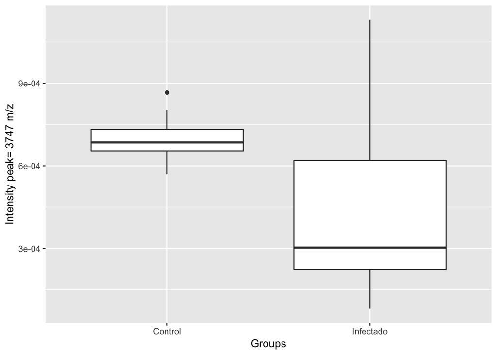

**Expasy**

Q5I4G1_RAT (Q5I4G1) SubName: Full=Spectrin beta-like polypeptide {ECO:0000313… Chain: 1-33, pI: 9.17, **Mw: 3748**

**interprot**

Submitted name: Spectrin beta-like polypeptide Gene: N/A Organism: Rattus norvegicus (Rat)

## Dudosos

### 6965

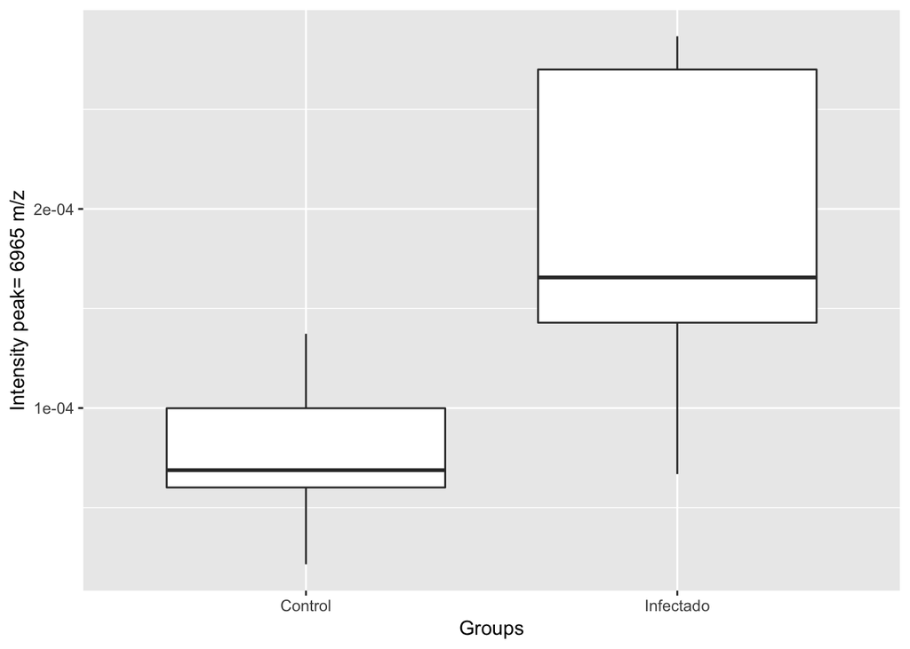

**Expasy**

M0R5G7_RAT (M0R5G7) SubName: Full=Keratin-associated protein 22-2 {ECO:000031… Chain: 1-67, pI: 8.59, **Mw: 6961**

**interprot**

The major structural proteins of mammalian hair are the hair keratin intermediate filaments (KIFs) and the keratin-associated proteins (KRTAPs). In the hair cortex, hair keratins are embedded in an inter-filamentous matrix consisting of KRTAPs which are essential for the formation of a rigid and resistant hair shaft as a result of disulphide bonds between cysteine residues. There are essentially three groups of KRTAPs, viz: the high-sulphur (HS) and ultra-high-sulphur (UHS) KRTAPs (cysteine content: 16-30 and >30 mol%, respectively) and the high-glycine/tyrosine (HGT: 35-60 mol% glycine and tyrosine) KRTAPs.

### 3225

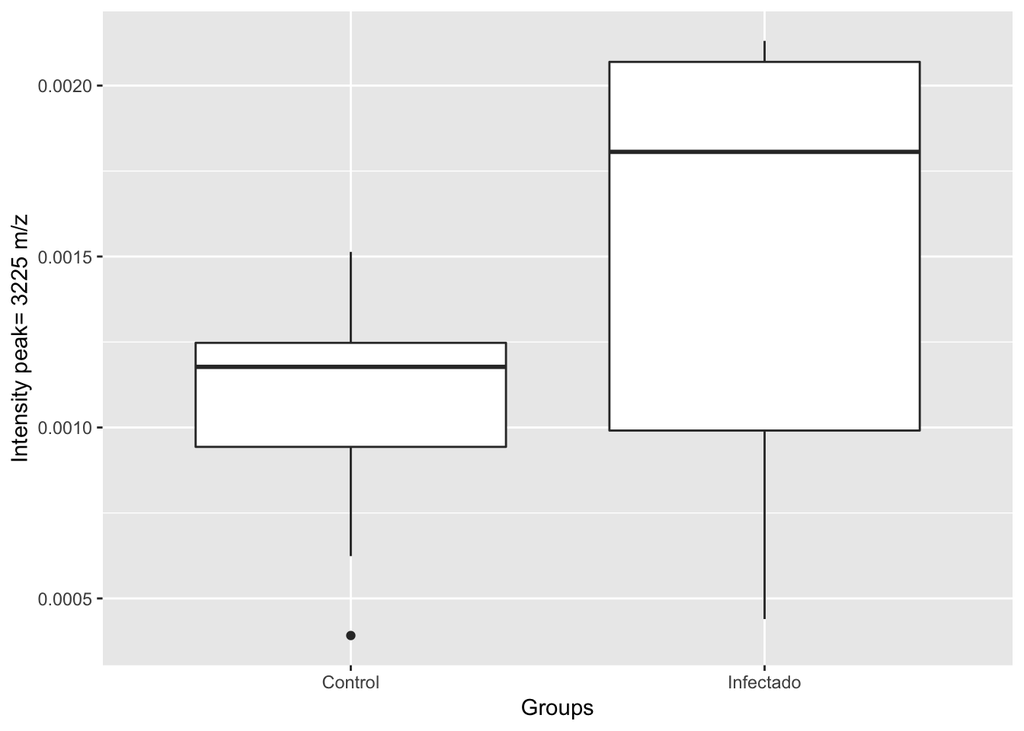

**Expasy**

CMGA_RAT (P10354) Serpinin-RRG. Chain: 438-466, pI: 4.54, **Mw: 3235**

La asignación podría no ser confiable, hay 10 Da de diferencia. De todas formas en el rango de PM buscado era la proteína más cercana.

**interprot**

Protein: Chromogranin-A Gene: Chga Organism: Rattus norvegicus (Rat)

Pancreastatin: Strongly inhibits glucose induced insulin release from the pancreas.

## No confiables

### 2690

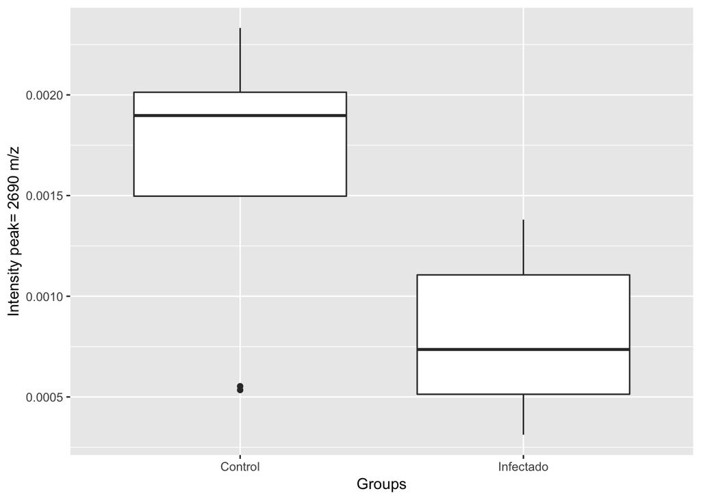

**Expasy**

ANF_RAT (P01161) Auriculin-B. Chain: 126-150, pI: 9.69, **Mw: 2708**

La diferencia de 18 Da es significativa, la asignación podría no ser confiable, aunque en ese rango era la proteína más cercana.

**interprot**

Protein: Natriuretic peptides A Gene: Nppa Organism: Rattus norvegicus (Rat)

Hormone playing a key role in cardiovascular homeostasis through regulation of natriuresis, diuresis, and vasodilation. Also plays a role in female pregnancy by promoting trophoblast invasion and spiral artery remodeling in uterus. Specifically binds and stimulates the cGMP production of the NPR1 receptor. Binds the clearance receptor NPR3

### 2031

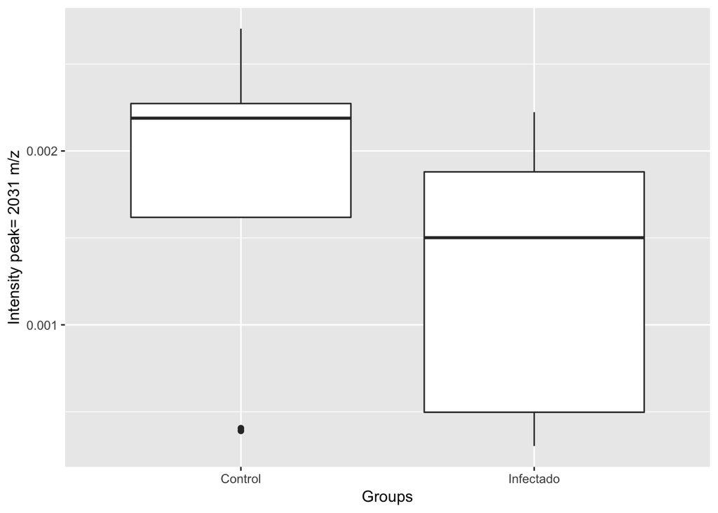

Muy cercano al límite de detección de la técnica, la diferencia de Da puede deberse a este hecho. En principio se considerarían ambos hits.

**Expasy1**

PCSK1_RAT (Q9QXU9) PEN-20. Chain: 221-240, pI: 3.44, **Mw: 2046**

**interprot1**

Protein: ProSAAS Gene: Pcsk1n Organism: Rattus norvegicus (Rat)

**Expasy2**

NPVF_RAT (Q9ESQ9) Neuropeptide NPVF. Chain: 108-125, pI: 6.79, **Mw: 2021**

**interprot2**

Neuropeptide RFRP-1 acts as a potent negative regulator of gonadotropin synthesis and secretion. Neuropeptides NPSF and NPVF efficiently inhibit forskolin-induced production of cAMP (By similarity). Neuropeptide NPVF blocks morphine-induced analgesia.

### 4020

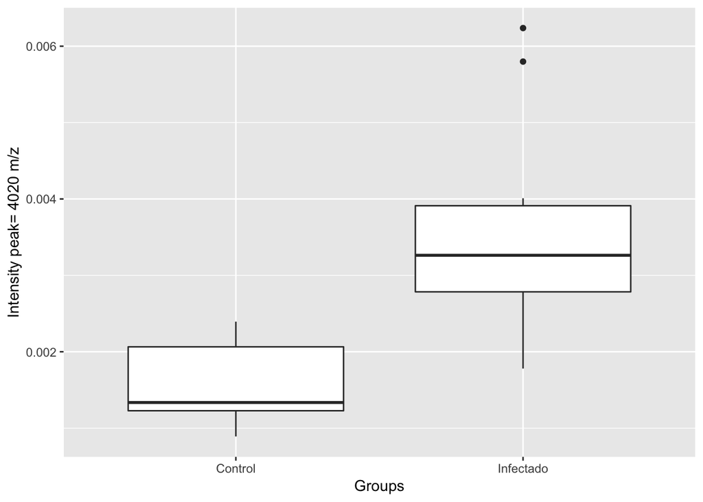

**Expasy**

GAST_RAT (P04563) Big gastrin. Chain: 59-92, pI: 4.48, **Mw: 3990**

La diferencia de 30 Da es significativa, la asignación podría no ser confiable, aunque en ese rango era la proteína más cercana.

**interprot**

Gastrin stimulates the stomach mucosa to produce and secrete hydrochloric acid and the pancreas to secrete its digestive enzymes. It also stimulates smooth muscle contraction and increases blood circulation and water secretion in the stomach and intestine.